# Distribución del pago de los servicios

#### Tabla de contenidos:

###### • Notas Preliminares

1. Gases del Caribe
2. AAA
   1. Datos de la factura
   2. Total pago por habitación
3. Air-e
   1. Datos de la factura
   2. Datos para tener en cuenta
      1. Diferencias sobre datos de consumo
      2. Valor de corte
      3. Lectura de contadores internos
      4. Consumo area común
   3. Total a pagar por habitación
4. Movistar
5. Total servicios

## Notas Preliminares

Sobre el documento: Como esta nueva plataforma me facilita la actualización de la información, trataré de ir actualizando el documento a medida que las facturas vayan llegando.

Valor del arriendo: a partir de este mes de septiembre, el valor del arriendo queda en $170.000 para las habitaciones grandes y $150.000 la pequeña.

## 1. Gases del Caribe

Datos de la factura del gas:

La factura de la casa grande (contrato No.1020307), por un valor total de $73.621 correspondiente al período 08/2025, está para pagar antes del 16 de septiembre de 2025.

NOTA: Del valor total me corresponde pagar: $31.800.

###### Tabla de contenidos

## 2. AAA

### 2.1. Datos de la factura

Los siguientes son los datos tomados de la factura de este mes:

La factura del agua (póliza No.121497), por un valor total de $290.680, correspondiente al período: Septiembre-2025, está para pagar antes del 12 de septiembre de 2025.

### 2.2. Total pago por habitación

| Habitación | Integrante(s) | Ocupación | Total AAA |
| --- | --- | --- | --- |
| Hab. 1 | Andresito y Kevin | 100.00% | $109.000 |
| Hab. 2 | Jorge | 100.00% | $54.500 |
| Hab. 3 | Gary | 33.33% | $18.200 |
| Apt. | Luis y Andrés | 100.00% | $109.000 |

###### Tabla de contenidos

## 3. Air-e

### 3.1. Datos de la factura:

Para el período Sep. - 2025, el valor total a pagar por la factura de energía eléctrica del NIC: 2345873 es de $255.190. Este valor corresponde a un consumo de 296 Kws desde el 21 de agosto de 2025 hasta el 19 de septiembre de 2025 (fecha de la lectura actual), y está para pagar antes del 25 de septiembre de 2025.

### 3.2. Datos para tener en cuenta

#### 3.2.1. Diferencias sobre datos de consumo

Entre los datos que reporta Air-e en sus lecturas y los recolectados de la información que suministran los contadores, aparecen diferencias de consumo. Estas diferencias no deben ser muy altas y se deben principalmente a la sección de la casa en la cual no se recolectan los datos, por esta razón los datos de Air-e van a estar mas altos que los reportados en el consumo interno. La siguiente tabla muestra estas diferencias para este mes:

| Factura Air-e | Lectura Contadores | Número de días | Diferencia |
| --- | --- | --- | --- |
| 296 Kw | 277.73 Kw | 30 días | 18.27 Kw |

La diferencia de estos consumos (última columna) se repartirá proporcionalmente al consumo de cada habitación.

#### 3.2.2. Valor de corte

Este valor permite observar las tendencias en el consumo mes a mes (aumentos o disminuciones en los promedios de consumo). De acuerdo al valor de corte de 10 Kw por día:

Este mes hemos disminuido el promedio de consumo en 0.133 Kw por día con respecto al corte.

#### 3.2.3. Lectura de contadores internos

A partir del presente mes se presentan en la siguiente tabla las lecturas de los contadores internos de cada subdivisión de los circuitos de la casa (Habitaciones y apartamento). Se les recuerda que el area común, desde la cocina hasta la lavandería, no han quedado cobijados bajo ningún contador por lo que la sumatoria de los valores de consumo de los contadores internos será menor al consumo total reportado por air-e, haciéndose necesaria la repartición de esta diferencia, la cual se hará de manera proporcional al consumo obtenido de los contadores.

| Habitación | Contador # | Lectura final | Lectura inicial | Consumo Kw |
| --- | --- | --- | --- | --- |
| Hab. 1 | 24177828 | 171.68 | 54.89 | 116.79 |
| Hab. 2 | 24178030 | 75.61 | 24.17 | 51.44 |
| Hab. 3 | 24176587 | 3.82 | 3.23 | 0.59 |
| Apt. | 24178159 | 157.85 | 48.94 | 108.91 |

```
La última lectura de los contadores internos se realizó el 19 de septiembre de 2025; la lectura anterior se hizo el 19 de agosto de 2025.

La suma total de los consumos es de 277.73 Kw. Quedando un consumo a repartir de 18.27 Kw.
```

#### 3.2.4. Consumo area común

Este consumo será repartido de manera proporcional al consumo reportado por los contadores internos de acuerdo a la siguiente tabla (todos los valores en Kw):

| Habitación | Consumo Contador | Consumo Area Común | Consumo Total por Hab. |
| --- | --- | --- | --- |
| Hab. 1 | 116.79 | 7.68 | 124.47 |
| Hab. 2 | 51.44 | 3.38 | 54.82 |
| Hab. 3 | 0.59 | 0.04 | 0.63 |
| Apt. | 108.91 | 7.16 | 116.07 |

### 3.3. Total a pagar por habitación

| Habitación | Integrante(s) | Costo Energía |
| --- | --- | --- |
| Hab. 1 | Andresito y Kevin | $107.300 |
| Hab. 2 | Jorge | $47.300 |
| Hab. 3 | Gary | $500 |
| Apt. | Luis y Andrés | $100.100 |

###### Tabla de contenidos

## 4. Movistar

Los siguientes son los datos de la factura de Movistar por concepto del internet:

El valor total de la factura del Internet por $91.404, con referencia de pago 60512751061, está para pagar antes del 10 de octubre de 2025. Equivalente a $18.300 por persona (5).

###### Tabla de contenidos

## 5. Total Servicios

El total de los servicios por habitación para este mes se discrimina en la siguiente tabla:

sept. 2025

| Habitación | AAA | Air-e | Movistar | Total Servicios |
| --- | --- | --- | --- | --- |
| Hab. 1 | $109.000 | $107.300 | $36.600 | $252.900 |
| Hab. 2 | $54.500 | $47.300 | $18.300 | $120.100 |
| Hab. 3 | $18.200 | $500 | $0 | $18.700 |
| Apt. | $109.000 | $100.100 | $36.600 | $245.700 |

La siguiente tabla corresponde a los valores del mes pasado:

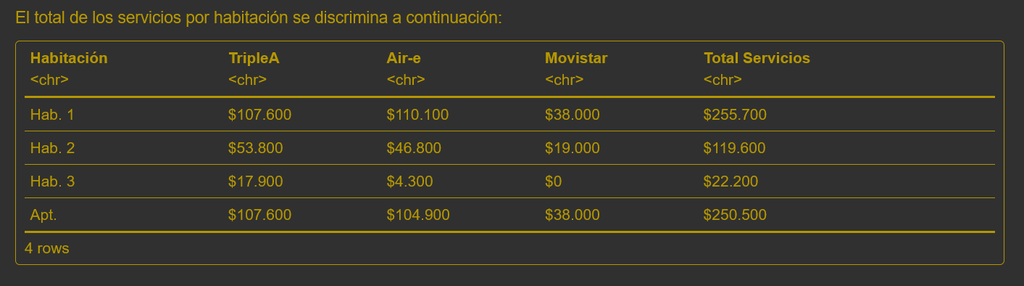

###### Tabla de contenidos